# Chapter 3 MSSM Method Development

## 3.1 Microbial Genomic Reference Data

### 3.1.1 Summary Statistics

#### Macro-scale MAG Catalogue

```
Completeness: median = 99.98 IQR = 94.6 - 100
```

```
Contamination: median = 0.23 IQR = 0 - 1.71
```

#### Micro-scale MAG Catalogue

```
Completeness: median = 96.94 IQR = 91.49 - 99.49
```

```
Contamination: median = 0.58 IQR = 0.21 - 1.83
```

### 3.1.5 Comparative Analysis Of Genome Catalogues (Suppl. Note 1)

```
Number Genomes in Macro-scale MAGs Catalogue = 223
```

```
Number Genomes in Micro-scale MAGs Catalogue = 122
```

```
Verification: The combined macro and micro dataset contains only unique species.
```

#### 3.1.5.1 Read Counts

```
Macro-scale genome catalogue:  median = 10.58 IQR = 7.72 - 14.21
```

```
Micro-scale genome catalogue:  median = 11.8 IQR = 8.54 - 16
```

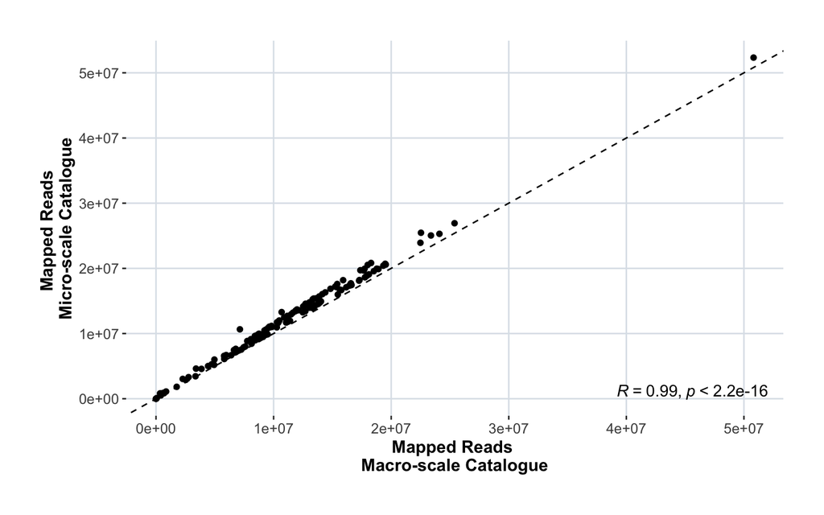

Read mapping results were strongly correlated across the two catalogues.

#### 3.1.5.2 Alpha Diversity (Fig. S1.1a)

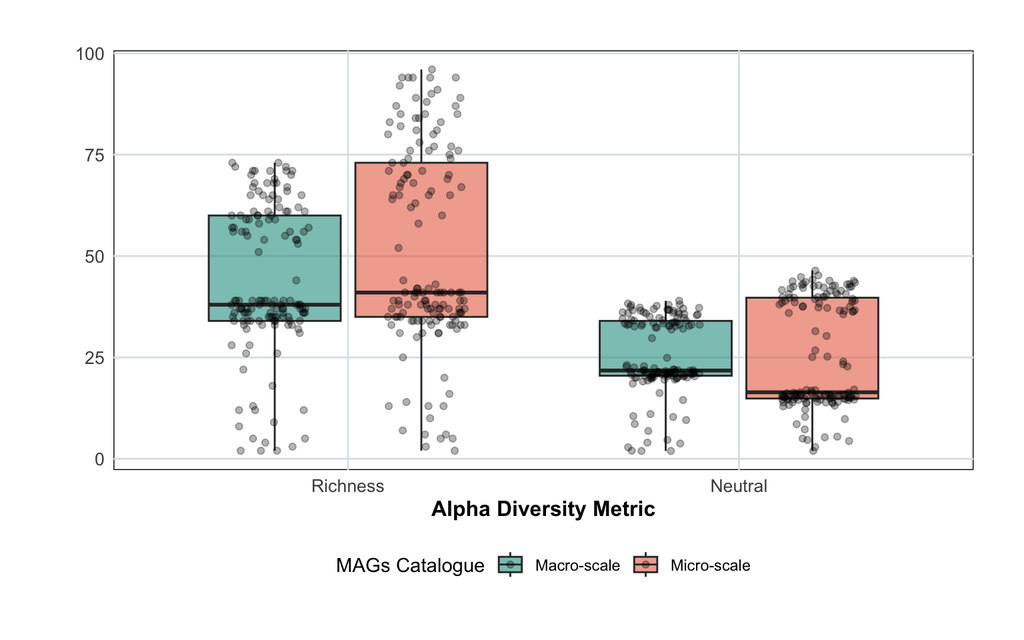

##### Richness

| statistic | p.value | method | alternative |
| --- | --- | --- | --- |
| 7486.5 | 1.590e-20 | Wilcoxon signed rank test with continuity correction | two.sided |

##### Neutral

| statistic | p.value | method | alternative |
| --- | --- | --- | --- |
| 5078 | 0.882 | Wilcoxon signed rank test with continuity correction | two.sided |

#### 3.1.5.3 Detected Taxa

##### Number Unique Species

```
Micro-scale MAGs Catalogue = 40
```

```
Macro-scale MAGs Catalogue = 8
```

##### Number Unique Genera

```
Micro-scale MAGs Catalogue = 28
```

```
Macro-scale MAGs Catalogue = 0
```

A greater number of unique taxa were detected with the microscale.

#### 3.1.5.4 Beta Diversity (Fig. S1.1b)

##### Centered Log-Ratio (CLR) Transformation And Principal Component Analysis (PCA)

```
Zero replacement determined
```

```
[1] "Zeros found"
No. adjusted imputations:  1410
Rows (samples) removed: 26
Columns (taxa) removed: 47
```

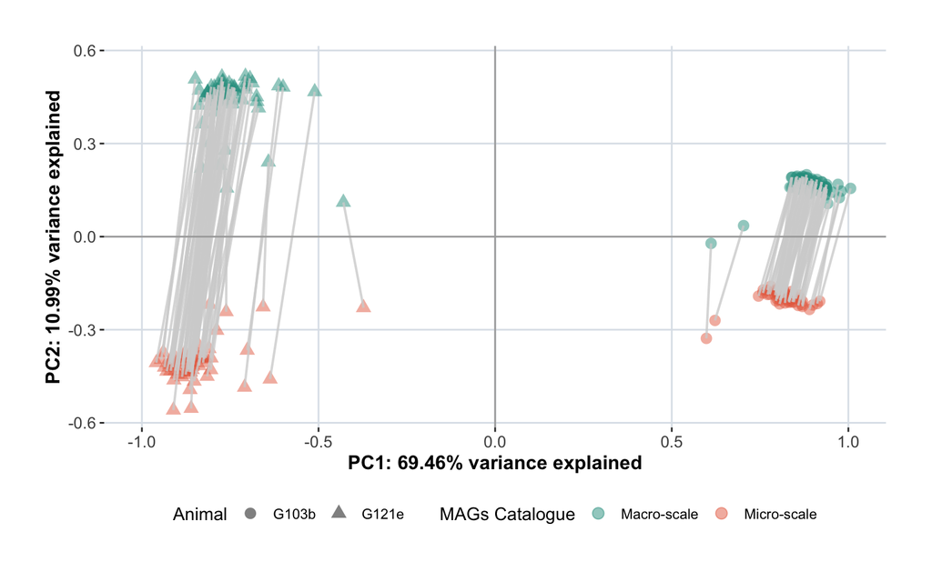

The 35-day-old animal (G121e) showed the greatest species-level differences between catalogues.

##### Differential Abundance (Aldex2)

```
|------------(25%)----------(50%)----------(75%)----------|
```

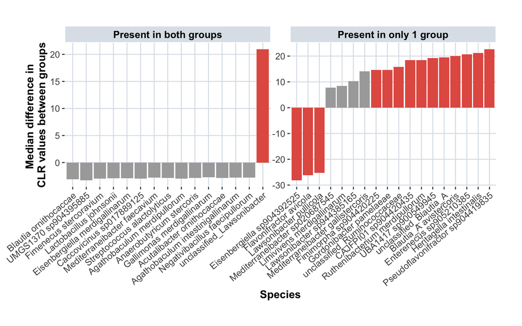

Differentially abundant species in the 35-day-old animal (G121e) are primarily structural 0.

## 3.2 Tissue Lysis And Sequencing Library Preparation (Suppl. Note 3)

### 3.2.1 Impact of Lysis Conditions On Microbial Taxonomic Profiling (Suppl. Note 3.2)

#### 3.2.1.2 Microsamples (Fig. S3.2.2)

##### 3.2.1.2.1 Visual Comparison Of Sequencing Performance (Fig. S3.2.2)

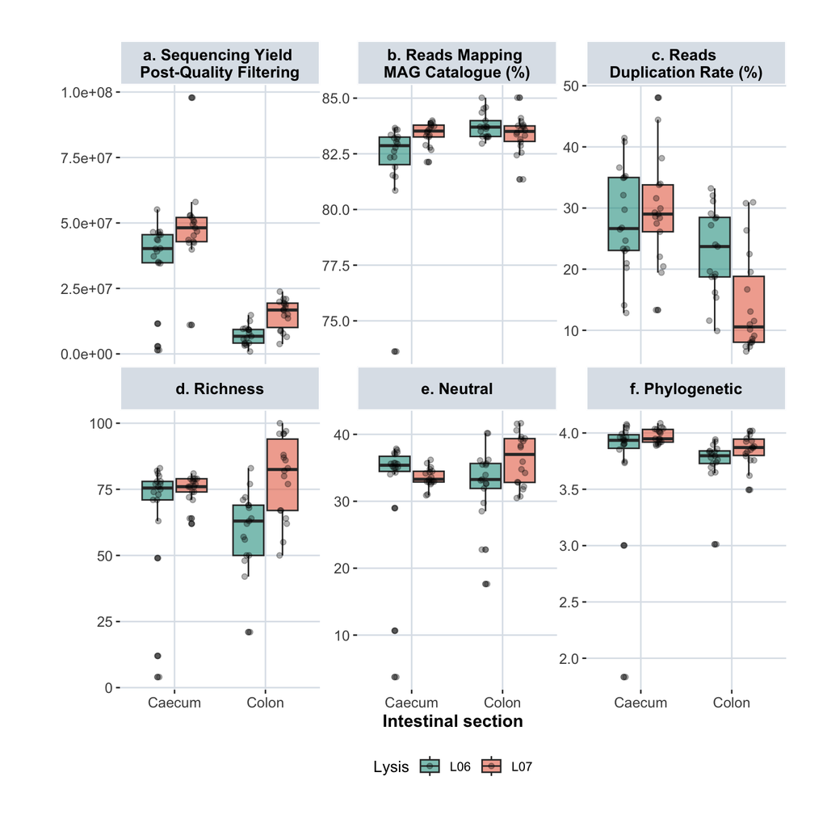

##### 3.2.1.2.2 Statistical Comparison Of Sequencing Performance

**Note:** The fit_and_analyze_model() function needs to be loaded.

###### a. Reads Retained Post Quality Filtering

###### Caecum

| term | sumsq | df | statistic | p.value |
| --- | --- | --- | --- | --- |
| collection_attempts | 18686423 | 3 | 1.003 | 0.405 |
| buffer | 42250297 | 1 | 6.802 | 0.014 |
| Residuals | 186338647 | 30 | NA | NA |

###### Colon

| term | sumsq | df | statistic | p.value |
| --- | --- | --- | --- | --- |
| collection_attempts | 6870290 | 2 | 1.732 | 0.194 |
| buffer | 46063248 | 1 | 23.230 | 0.000 |
| Residuals | 61470462 | 31 | NA | NA |

###### b. Reads Mapping MAG Catalogue (%)

###### Caecum

| term | sumsq | df | statistic | p.value |
| --- | --- | --- | --- | --- |
| collection_attempts | 0.002 | 3 | 0.382 | 0.767 |
| buffer | 0.010 | 1 | 4.837 | 0.036 |
| Residuals | 0.061 | 30 | NA | NA |

###### Colon

| term | sumsq | df | statistic | p.value |
| --- | --- | --- | --- | --- |
| collection_attempts | 0.001 | 2 | 1.854 | 0.174 |
| buffer | 0.001 | 1 | 3.882 | 0.058 |
| Residuals | 0.010 | 31 | NA | NA |

###### c. Reads Duplication Rate (%)

###### Caecum

| term | sumsq | df | statistic | p.value |
| --- | --- | --- | --- | --- |
| collection_attempts | 0.009 | 3 | 0.075 | 0.973 |
| buffer | 0.017 | 1 | 0.426 | 0.519 |
| Residuals | 1.174 | 30 | NA | NA |

###### Colon

| term | sumsq | df | statistic | p.value |
| --- | --- | --- | --- | --- |
| collection_attempts | 0.173 | 2 | 2.161 | 0.132 |
| buffer | 0.357 | 1 | 8.944 | 0.005 |
| Residuals | 1.238 | 31 | NA | NA |

###### Caecum

| term | sumsq | df | statistic | p.value |
| --- | --- | --- | --- | --- |
| collection_attempts | 9.381 | 3 | 0.689 | 0.566 |
| buffer | 12.508 | 1 | 2.755 | 0.107 |
| Residuals | 136.200 | 30 | NA | NA |

###### Colon

| term | sumsq | df | statistic | p.value |
| --- | --- | --- | --- | --- |
| collection_attempts | 10.762 | 2 | 1.695 | 0.200 |
| buffer | 41.227 | 1 | 12.988 | 0.001 |
| Residuals | 98.402 | 31 | NA | NA |

###### Caecum

| term | df | statistic | p.value |
| --- | --- | --- | --- |
| collection_attempts | 3 | 2.736 | 0.434 |
| buffer | 1 | 0.869 | 0.351 |

###### Colon

| term | df | statistic | p.value |
| --- | --- | --- | --- |
| collection_attempts | 2 | 4.034 | 0.133 |
| buffer | 1 | 4.409 | 0.036 |

```
Number Unique Genus in:
```

```
L06 = 1
```

```
L07 = 10
```

###### Caecum

| term | df | statistic | p.value |
| --- | --- | --- | --- |
| collection_attempts | 3 | 2.193 | 0.533 |
| buffer | 1 | 3.561 | 0.059 |

###### Colon

| term | df | statistic | p.value |
| --- | --- | --- | --- |
| collection_attempts | 2 | 1.927 | 0.382 |
| buffer | 1 | 3.882 | 0.049 |

### 3.2.2 Performance Evaluation Across Intestinal Sections (Suppl. Note 3.3)

#### 3.2.2.1 Visual Comparison Of Sequencing Performance (Fig. S3.3.1)

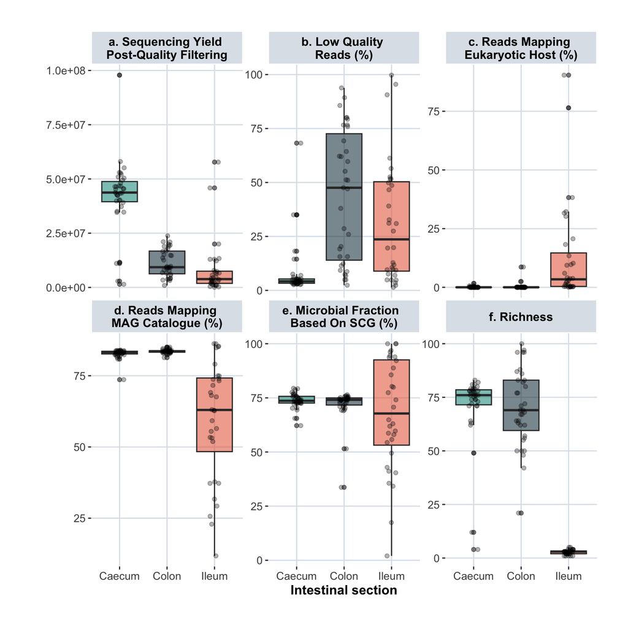

Library-building performance, evaluated using sequencing and diversity metrics, was highest in the caecum, lower in the colon, and poorest in the ileum.

#### 3.2.2.2 Statistical Comparison Of Sequencing Performance

##### a. Reads Retained Post Quality Filtering

```
Anova
```

| term | sumsq | df | statistic | p.value |
| --- | --- | --- | --- | --- |
| collection_attempts | 40627645 | 3 | 1.489 | 0.222 |
| section | 1104588118 | 2 | 60.735 | 0.000 |
| Residuals | 872972895 | 96 | NA | NA |

```
Predicted values from model
```

| x | predicted | std.error | conf.low | conf.high | group |
| --- | --- | --- | --- | --- | --- |
| Caecum right | 41540698 | 0.096 | 34337045 | 50255624 | 1 |
| Ileum | 7807323 | 0.205 | 5197343 | 11727973 | 1 |
| Colon | 9882423 | 0.172 | 7020420 | 13911175 | 1 |

##### b. Low Quality Reads (%)

```
Anova
```

| term | sumsq | df | statistic | p.value |
| --- | --- | --- | --- | --- |
| collection_attempts | 3.704 | 3 | 4.180 | 0.008 |
| section | 15.273 | 2 | 25.851 | 0.000 |
| Residuals | 28.359 | 96 | NA | NA |

```
Predicted values from model
```

| x | predicted | std.error | conf.low | conf.high | group |
| --- | --- | --- | --- | --- | --- |
| Caecum right | 0.074 | 0.379 | 0.036 | 0.145 | 1 |
| Ileum | 0.353 | 0.257 | 0.247 | 0.476 | 1 |
| Colon | 0.511 | 0.223 | 0.402 | 0.619 | 1 |

##### c. Reads Mapping Eukaryotic Host (%)

```
Anova
```

| term | sumsq | df | statistic | p.value |
| --- | --- | --- | --- | --- |
| collection_attempts | 2.154 | 3 | 5.019 | 0.003 |
| section | 10.395 | 2 | 36.325 | 0.000 |
| Residuals | 13.735 | 96 | NA | NA |

```
Predicted values from model
```

| x | predicted | std.error | conf.low | conf.high | group |
| --- | --- | --- | --- | --- | --- |
| Caecum right | 0.001 | 2.071 | 0.000 | 0.053 | 1 |
| Ileum | 0.146 | 0.283 | 0.089 | 0.231 | 1 |
| Colon | 0.002 | 1.170 | 0.000 | 0.017 | 1 |

##### d. Reads Mapping MAG Catalogue (%)

```
Anova
```

| term | sumsq | df | statistic | p.value |
| --- | --- | --- | --- | --- |
| collection_attempts | 0.211 | 3 | 1.246 | 0.297 |
| section | 5.675 | 2 | 50.322 | 0.000 |
| Residuals | 5.414 | 96 | NA | NA |

```
Predicted values from model
```

| x | predicted | std.error | conf.low | conf.high | group |
| --- | --- | --- | --- | --- | --- |
| Caecum right | 0.841 | 0.120 | 0.806 | 0.870 | 1 |
| Ileum | 0.615 | 0.109 | 0.563 | 0.665 | 1 |
| Colon | 0.840 | 0.124 | 0.804 | 0.870 | 1 |

##### e. Microbial Fraction Based On Single-Copy Gene Abundance (%)

```
Anova
```

| term | sumsq | df | statistic | p.value |
| --- | --- | --- | --- | --- |
| collection_attempts | 0.297 | 3 | 0.914 | 0.437 |
| section | 0.394 | 2 | 1.820 | 0.167 |
| Residuals | 10.396 | 96 | NA | NA |

```
Predicted values from model
```

| x | predicted | std.error | conf.low | conf.high | group |
| --- | --- | --- | --- | --- | --- |
| Caecum right | 0.748 | 0.143 | 0.690 | 0.797 | 1 |
| Ileum | 0.677 | 0.152 | 0.608 | 0.739 | 1 |
| Colon | 0.723 | 0.144 | 0.662 | 0.777 | 1 |

```
Correlation
```

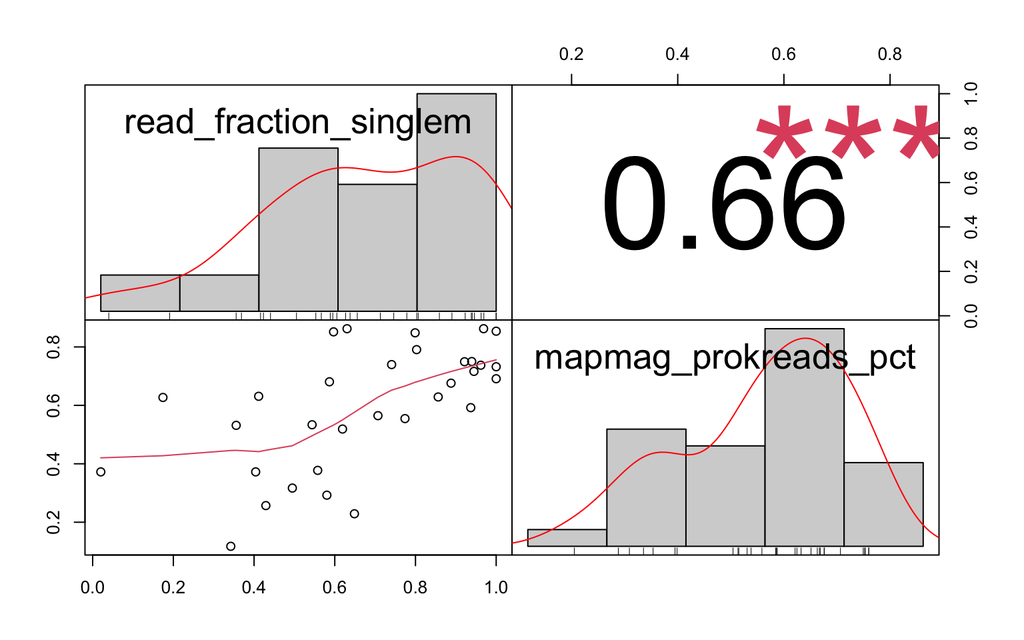

Single-copy gene analysis showed a moderate correlation with the proportion of reads mapping to the reference post-filtering.

#### 3.2.2.3 Colon: 19 Versus 15 Cycles

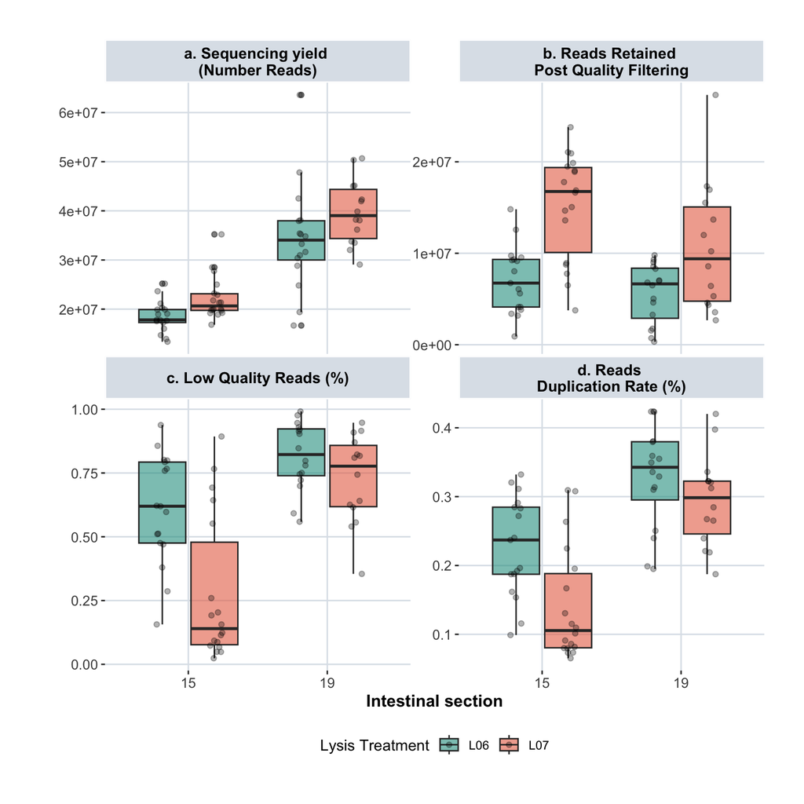

##### a. Sequencing Yield (Number Reads)

```
Anova
```

| term | sumsq | df | statistic | p.value |
| --- | --- | --- | --- | --- |
| collection_attempts | 492386.6 | 2 | 0.150 | 0.861 |
| cycles | 154708029.9 | 1 | 94.323 | 0.000 |
| Residuals | 100052058.2 | 61 | NA | NA |

```
Predicted values from model
```

| x | predicted | std.error | conf.low | conf.high | group |
| --- | --- | --- | --- | --- | --- |
| 15 | 20601289 | 0.055 | 18470098 | 22978390 | 1 |
| 19 | 37405618 | 0.048 | 34008351 | 41142255 | 1 |

##### b. Reads Retained Post Quality Filtering

```
Anova
```

| term | sumsq | df | statistic | p.value |
| --- | --- | --- | --- | --- |
| collection_attempts | 28529368 | 2 | 4.135 | 0.021 |
| cycles | 16953446 | 1 | 4.915 | 0.030 |
| Residuals | 210414932 | 61 | NA | NA |

```
Predicted values from model
```

| x | predicted | std.error | conf.low | conf.high | group |
| --- | --- | --- | --- | --- | --- |
| 15 | 9189837 | 0.123 | 7186626 | 11751426 | 1 |
| 19 | 6542893 | 0.147 | 4873356 | 8784389 | 1 |

##### c. Low Quality Reads (%)

```
Anova
```

| term | sumsq | df | statistic | p.value |
| --- | --- | --- | --- | --- |
| collection_attempts | 1.572 | 2 | 3.112 | 0.052 |
| cycles | 7.880 | 1 | 31.209 | 0.000 |
| Residuals | 15.403 | 61 | NA | NA |

```
Predicted values from model
```

| x | predicted | std.error | conf.low | conf.high | group |
| --- | --- | --- | --- | --- | --- |
| 15 | 0.511 | 0.207 | 0.409 | 0.613 | 1 |
| 19 | 0.829 | 0.272 | 0.738 | 0.893 | 1 |

##### d. Reads Duplication Rate (%)

```
Anova
```

| term | sumsq | df | statistic | p.value |
| --- | --- | --- | --- | --- |
| collection_attempts | 0.270 | 2 | 3.721 | 0.03 |
| cycles | 1.443 | 1 | 39.815 | 0.00 |
| Residuals | 2.211 | 61 | NA | NA |

```
Predicted values from model
```

| x | predicted | std.error | conf.low | conf.high | group |
| --- | --- | --- | --- | --- | --- |
| 15 | 0.203 | 0.094 | 0.174 | 0.236 | 1 |
| 19 | 0.342 | 0.091 | 0.302 | 0.384 | 1 |

Efforts to compensate for low biomass in the colon by increasing PCR cycles did not improve the quality of colon results.

#### 3.2.2.4 Community Composition of Caecum & Colon (Fig. S3.3.2)

**Note:** The pivot_phylo() function needs to be loaded.

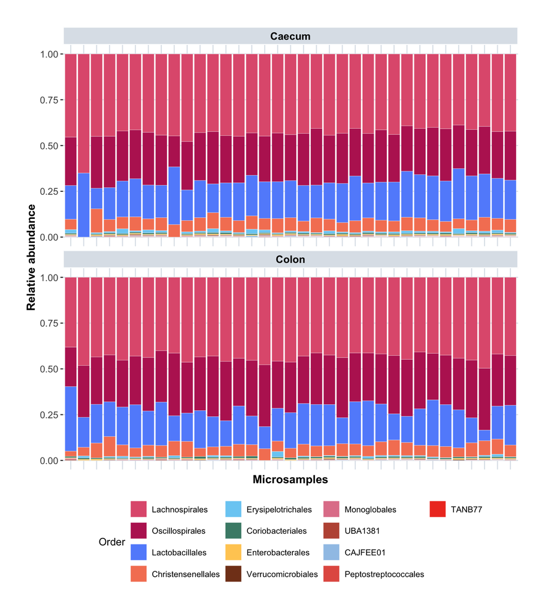

##### Differential Abundance (Aldex2)

```
|------------(25%)----------(50%)----------(75%)----------|
```

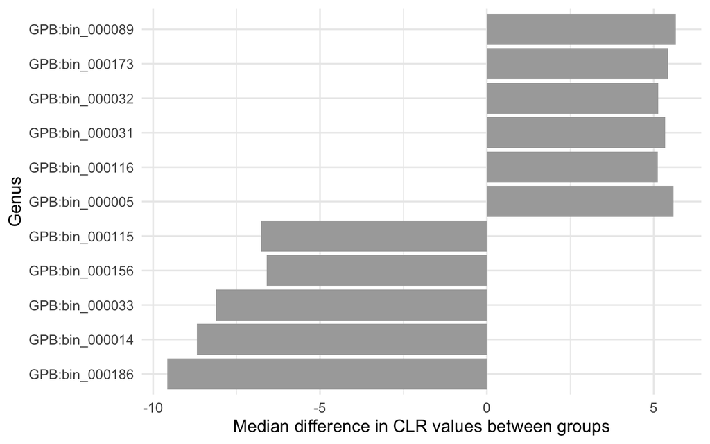

#### 3.2.2.5 Confocal Microscopy Of DAPI-stained Microsections (Fig. S3.3.3a)

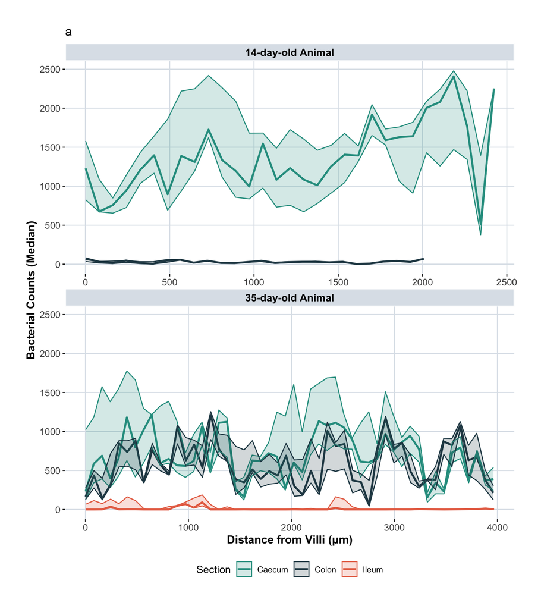

Quantification of bacterial cells within a 5,000 μm² area using QuPath provides visual confirmation that differences in bacterial density across intestinal regions (caecum, colon, and ileum) were the primary factor influencing MSSM performance.

## 3.3 Design Considerations: Controls (Suppl. Note 3.4)

### 3.3.1 Visual Comparison Of Sequencing Performance (Fig. S3.4.1)

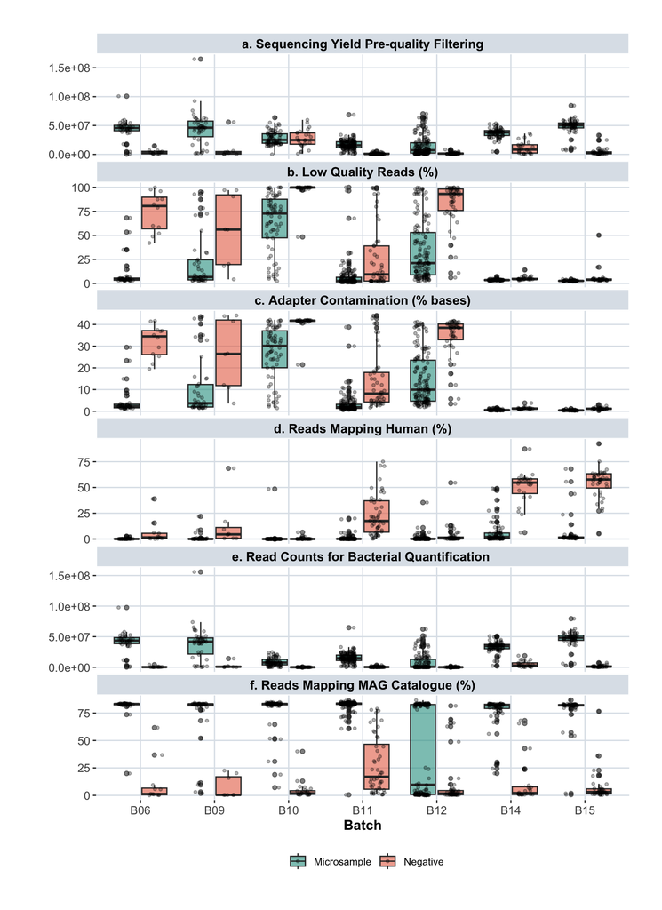

Although controls yielded sequencing data, they consistently exhibited poorer quality metrics.

### 3.3.2 Centered Log-Ratio (CLR) Transformation And Principal Component Analysis (PCA)

#### 3.3.2.2 FigS3_4_3

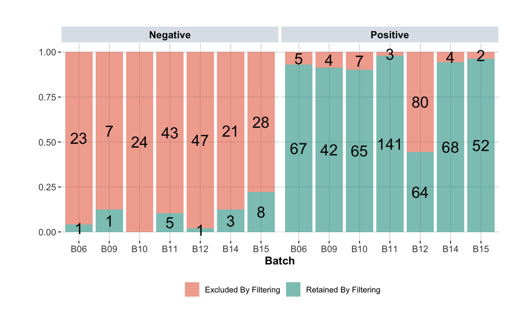

#### 3.3.2.3 Coverage Cutoff Filtering (Fig. S3.4.3)

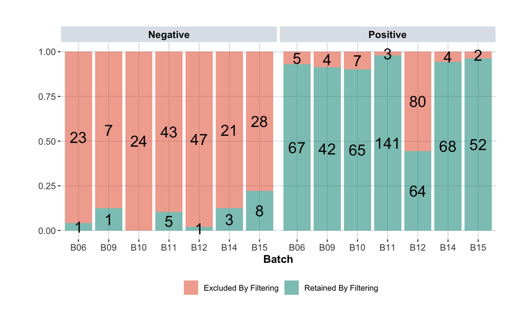

#### 3.3.2.4 Composition

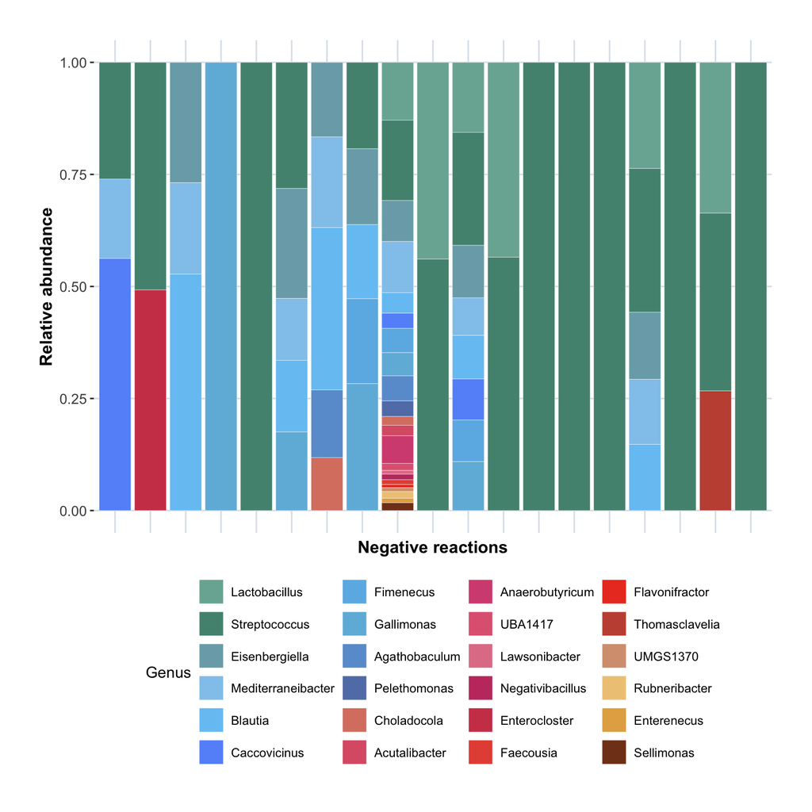

Elevated levels of Streptococcus were observed in negative reactions.

## 3.4 Design Considerations: Microsample Area

## 3.5 Resource Optimisation and Throughput (Suppl. Note 3.5)

### 3.5.1 Summary Statistic

|  | 100% | 50% | Automation (1 plate set-up) | Manual |
| --- | --- | --- | --- | --- |
| low_quality_reads_md | 11.95 | 3.30 | 2.60 | 3.55 |
| mapping_host_md | 0 | 0 | 0 | 0 |
| mapping_human_md | 0.00 | 0.00 | 1.35 | 1.20 |
| mapping_pig_md | 0 | 0 | 0 | 0 |
| mapping_bacteria_md | 72.40 | 80.45 | 78.85 | 78.65 |
| unmapped_bacteria_md | 15.2 | 16.2 | 17.0 | 16.6 |
| other_md | 0 | 0 | 0 | 0 |

#### 3.5.1.1 Visual Comparison Of Sequencing Performance (Fig. S3.5.1a)

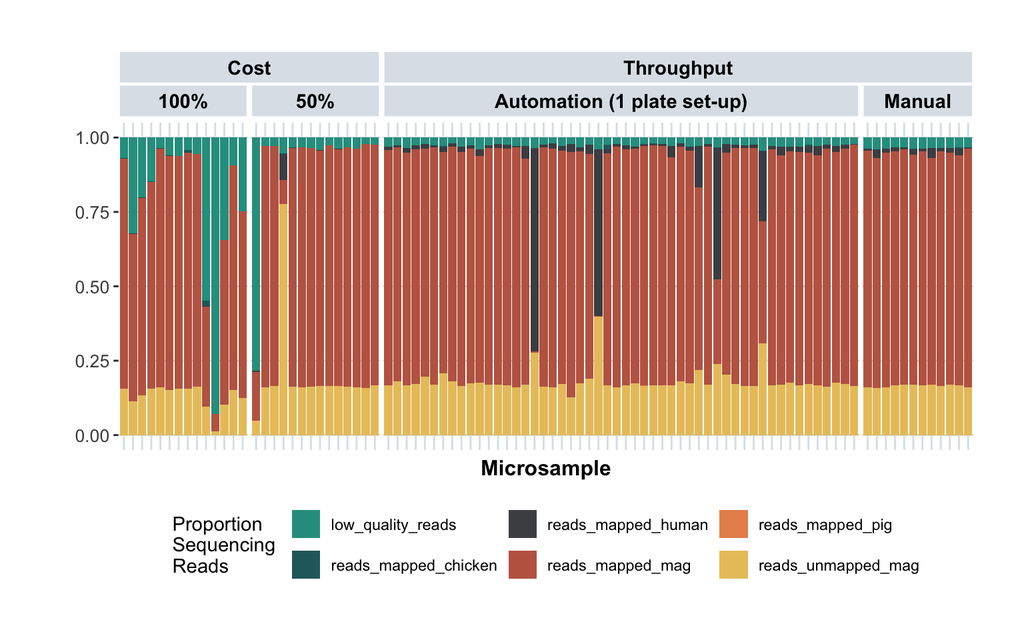

#### 3.5.1.2 Visual Comparison Of Library Preparation Efficiency (Fig. S3.5.1b)

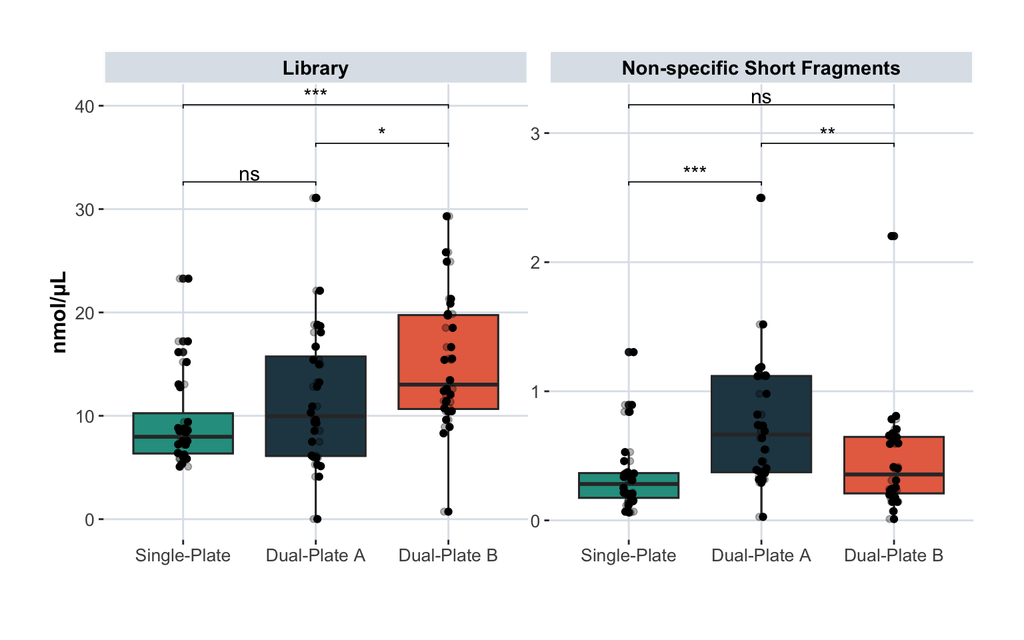